# Practicals — Introduction to Bayesian analysis for medical studies — Solutions to exercise 4

Boris Hejblum

May 14<sup>th</sup> 2019

# Exercise 4: Introduction to `BUGS` & `JAGS`

The [BUGS project](https://www.mrc-bsu.cam.ac.uk/software/bugs/) (*Bayesian inference Using Gibbs Sampling*) was initiated in 1989 by the MRC (*Medical Research Council*) Biostatistical Unit at the University of Cambridge (United-Kingdom) to develop a flexible and user-friendly software for Bayesian analysis of complex models through MCMC algorithms. Its most famous and original implementation is `WinBUGS`, a clicking software available under *Windows*. `OpenBUGS` is an alternative implementation of `WinBUGS` running on either *Windows*, *Mac OS* ou *Linux*. [`JAGS`](http://mcmc-jags.sourceforge.net/) (*Just another Gibbs Sampler*) is a different and newer implementation that also relies on the `BUGS` language. Finally, the [`STAN`](http://mc-stan.org/) software must also be mentionned, recently developed et the Columbia Univeristy, ressemble `BUGS` through its interface, but relies on innovative MCMC approaches, such as Hamiltonian Monte Carlo, or variational Bayes approaches. A very useful resource is the [JAGS user manual](http://sourceforge.net/projects/mcmc-jags/files/Manuals/3.x/jags_user_manual.pdf).

To familiarise yourself with `JAGS` (and its `R` interface through the package `rjags`), we will look here at the *posterior* estimation of the mean and variance of observed data that we will model with a Gaussian distribution.

0. load the `R` package `rjags`.

   ```r
   library(rjags)
   ```

A `BUGS` model has 3 components:

- *the model*: specified in an external text file (`.txt`) according to a specific `BUGS` syntax
- *the data*: a list containing each observation under a name matching the one used in the model specification
- *the initial values*: (optional) a list containing the initial values for the various parameters to be estimated
1. Sample $N=50$ observations from a Gaussian distribution with mean $m = 2$ and standard deviation $s = 3$ using the `R` function `rnorm`.

   ```r
   N <- 50  # the number of observations
   obs <- rnorm(n = N, mean = 2, sd = 3)  # the observed data
   ```

2. Read the help of the `rjags` package, then save a text file (`.txt`) the following code defining the `BUGS` model:

   ```
   # Model
   model{

     # Likelihood
     for (i in 1:N){
       obs[i]~dnorm(mu,tau)
     }

     # Prior
     mu~dnorm(0,0.0001) # proper but very flat (weakly informative)
     tau~dgamma(0.0001,0.0001) # proper but very flat (weakly informative)

     # Variables of interest
     sigma <- pow(tau, -0.5)
   }
   ```

Each model specification file must start with the instruction `model{` indicating `JAGS` it is about to recieve a model specification. Then the model must be set up, usually by cycling along the data with a `for` loop. Here, we want to declare `N` observations, and each of them `obs[i]` follows a Gaussian distribution (characterized with the command `dnorm`) of mean `mu` and precision `tau`. *Warning*: in `BUGS`, the Gaussian distribution is parametrized by its precision, which is simply the inverse of the variance ($\tau = 1/\sigma^2$). Then, one needs to define the *prior* distribution for each parameter, here both `mu` and `tau`. For `mu`, we use a Gaussian *prior* with mean $0$ and precision $10^{-4}$ (thus variance $10,000$: this corresponds correspond to a weakly informative *prior* and quite spread out given the sale of our data. For `tau` we use the conjugate *prior* for precision in a Gaussian model, namely the Gamma distribution (with vely small parameters, here again to remain the less informative possible). Finally, we give a deterministic definition of the additional parameters of interest, here the standard deviation `sigma`.

3. With the `R` function `jags.model()`, create a `jags` object `R`.

   ```r
   myfirstjags <- jags.model("normalBUGSmodel.txt", data = list(obs = obs, N = length(obs)))
   ```

4. With the `R` function `coda.samples()`, generate a sample of size $2,000$ from the *posterior* distibutions for the mean and standard deviation parameters de moyenne et de variance.

   ```r
   res <- coda.samples(model = myfirstjags, variable.names = c("mu", "sigma"),
       n.iter = 2000)
   ```

5. Study the output of the `coda.samples()` `R` function, and compute both the *posterior* mean and median estimates for `mu` and `sigma`. Give a credibility interval at 95% for both.

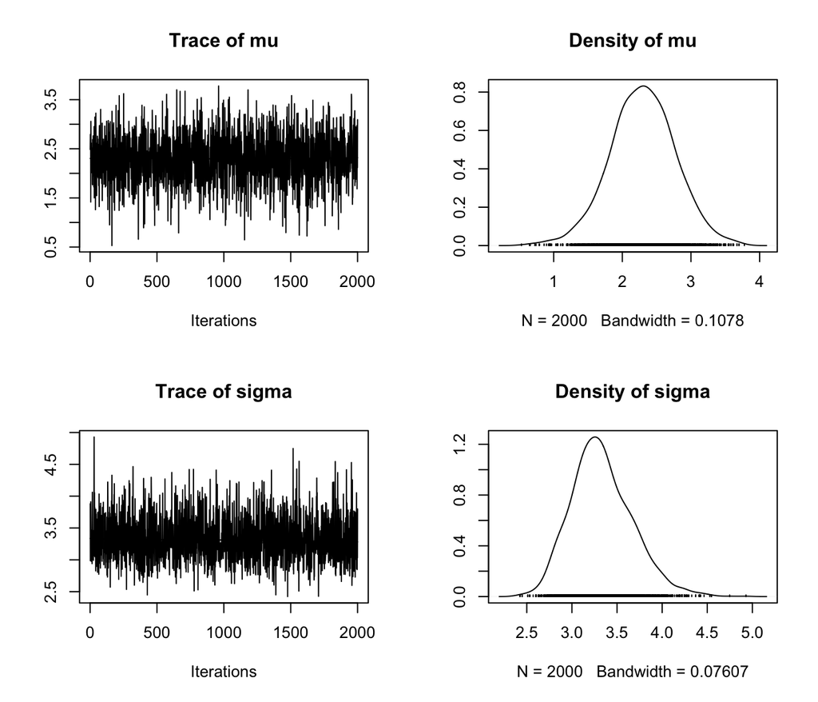

   ```r
   plot(res)
   ```

   ```r
   resum <- summary(res)
   resum
   ```

   ```
   ##
   ## Iterations = 1:2000
   ## Thinning interval = 1
   ## Number of chains = 1
   ## Sample size per chain = 2000
   ##
   ## 1. Empirical mean and standard deviation for each variable,
   ##    plus standard error of the mean:
   ##
   ##        Mean     SD Naive SE Time-series SE
   ## mu    2.296 0.4793 0.010717       0.010717
   ## sigma 3.332 0.3400 0.007602       0.008044
   ##
   ## 2. Quantiles for each variable:
   ##
   ##        2.5%   25%   50%   75% 97.5%
   ## mu    1.319 1.986 2.297 2.609 3.225
   ## sigma 2.758 3.100 3.300 3.540 4.058
   ```

   ```r
   resum$statistics["mu", "Mean"]
   ```

   ```
   ## [1] 2.295712
   ```

   ```r
   resum$statistics["sigma", "Mean"]
   ```

   ```
   ## [1] 3.331723
   ```

   ```r
   resum$quantiles["mu", "50%"]
   ```

   ```
   ## [1] 2.296788
   ```

   ```r
   resum$quantiles["sigma", "50%"]
   ```

   ```
   ## [1] 3.30035
   ```

   ```r
   resum$quantiles["mu", c(1, 5)]
   ```

   ```
   ##     2.5%    97.5%
   ## 1.319371 3.225163
   ```

   ```r
   resum$quantiles["sigma", c(1, 5)]
   ```

   ```
   ##     2.5%    97.5%
   ## 2.758338 4.057688
   ```

6. Load the `coda` `R` package. This package functions for convergence diagnostic and analysis of MCMC algorithm outputs.

   ```r
   library(coda)
   ```

7. To diagnose the convergence of an MCMC algorithm, it is necessary to generate different Markov chains, with different initial values. Recreate a new `jags` object in `R` and specify the use of 3 Markov chains with the argument `n.chains`, and initialize `mu` and `tau` at $(0, -10, 100)$ and $(1, 0.01, 0.1)$ respectively with the argument `inits`. Comment.

   ```r
   myjags2 <- jags.model("normalBUGSmodel.txt", data = list(obs = obs, N = N),
       n.chains = 3, inits = list(list(mu = 0, tau = 1), list(mu = -10, tau = 1/100),
           list(mu = 100, tau = 1/10)))
   ```

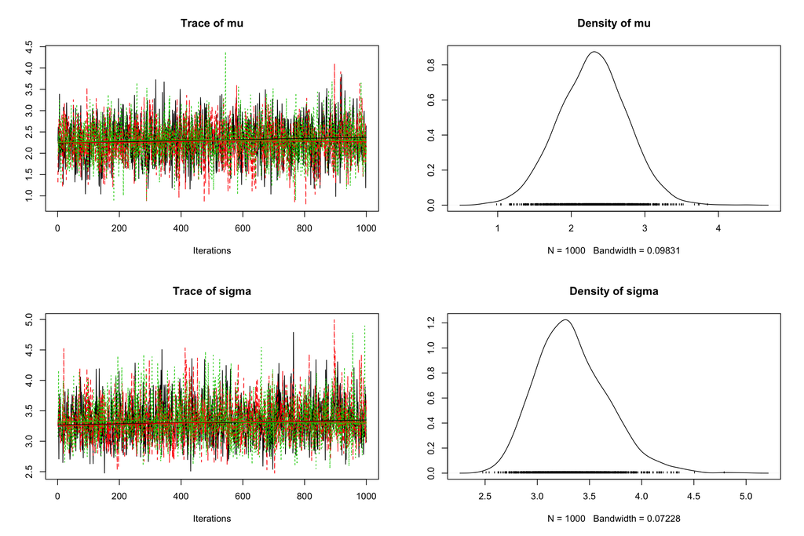

   ```r
   res2 <- coda.samples(model = myjags2, variable.names = c("mu", "sigma"), n.iter = 1000)
   plot(res2)
   ```

8. With the `R` function `gelman.plot()`, plot the Gelman-Rubin statistic.

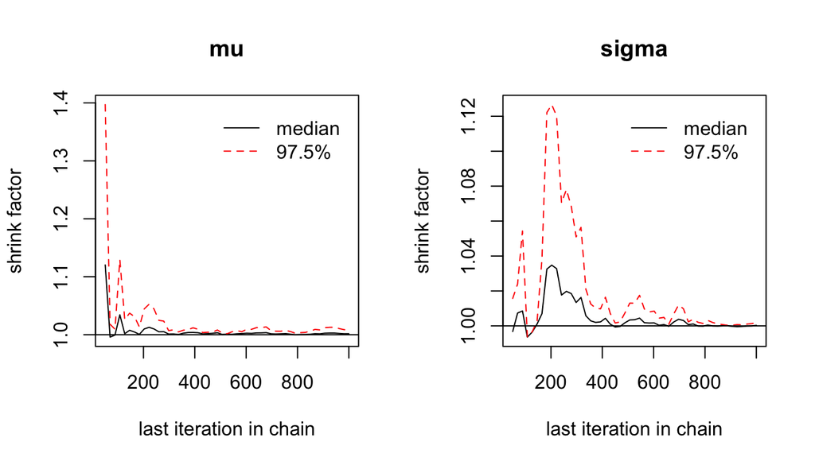

   ```r
   gelman.plot(res2)
   ```

9. With the `R` functions `autocorr.plot()` and `acfplot()` evaluate the autocorrélation of the studied parameters.

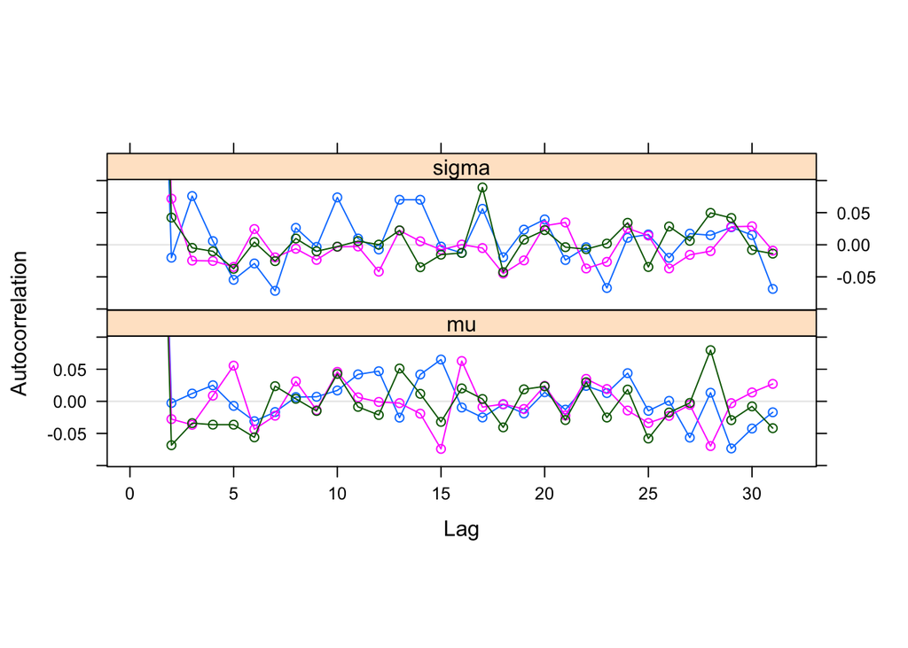

   ```r
   acfplot(res2)
   ```

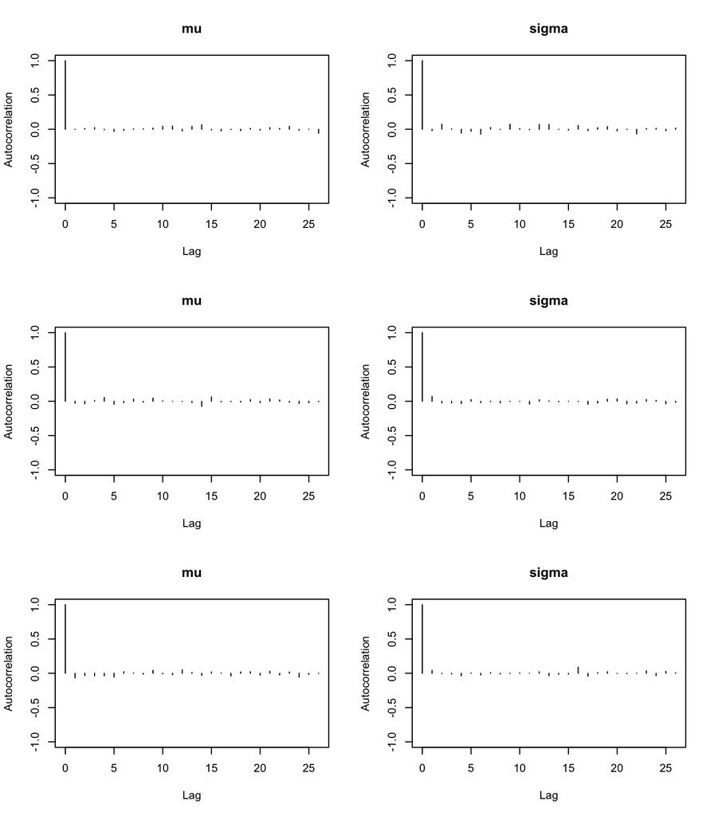

   ```r
   par(mfrow = c(3, 2))
   autocorr.plot(res2, ask = FALSE, auto.layout = FALSE)
   ```

10. With the `R` function `cumuplot()` evaluate the running quantiles of the studied parameters. How can you interpret them ?

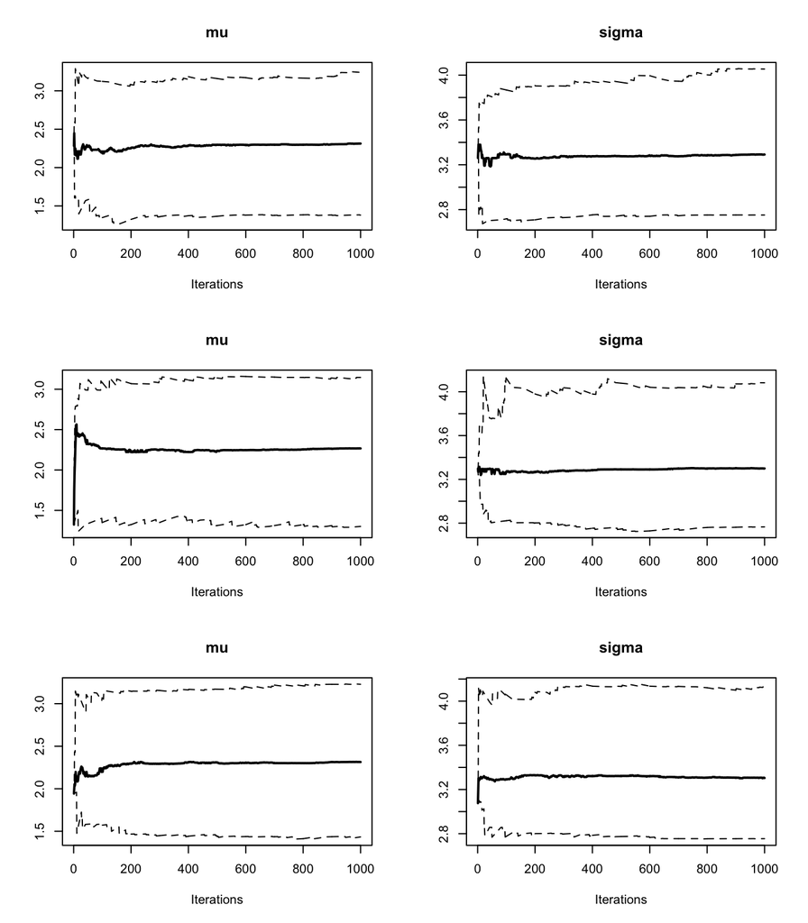

    ```r
    par(mfrow = c(3, 2))
    cumuplot(res2, ask = FALSE, auto.layout = FALSE)
    ```

11. With the `R` function `crosscorr.plot()` evaluate the correlations between the studied parameters. How can you interpret them ?

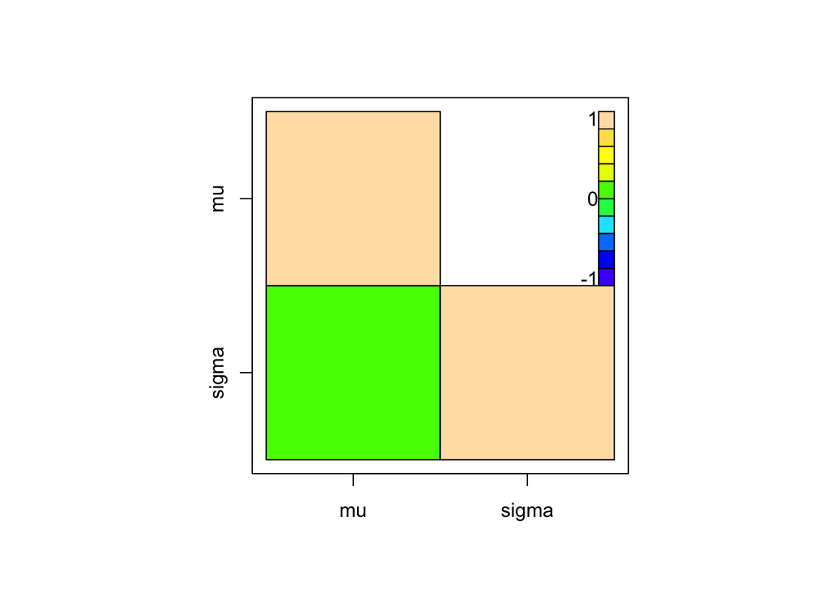

    ```r
    crosscorr.plot(res2)
    ```

12. With the function `hdi()` from the `R` package `HDInterval`, provide highest densitity *posterior* credibility intervals at 95%, and compare themto those obtained with the $2.5$% and $97.5$% quantiles.

    ```r
    hdCI <- HDInterval::hdi(res2)
    hdCI
    ```

    ```
    ##             mu    sigma
    ## lower 1.377738 2.690965
    ## upper 3.171811 3.997238
    ## attr(,"credMass")
    ## [1] 0.95
    ```

    ```r
    symCI <- summary(res2)$quantiles[, c(1, 5)]
    symCI
    ```

    ```
    ##           2.5%    97.5%
    ## mu    1.383717 3.189438
    ## sigma 2.754053 4.087278
    ```

    ```r
    symCI[, 2] - symCI[, 1]
    ```

    ```
    ##       mu    sigma
    ## 1.805721 1.333225
    ```

    ```r
    hdCI[2, ] - hdCI[1, ]
    ```

    ```
    ##       mu    sigma
    ## 1.794073 1.306273
    ```